# Sub-setting Indianapolis Crashes from the ARIES dataset

Daniel Riggins, MD

2020-03-26

## Rationale

In [a previous report](https://nbviewer.jupyter.org/github/andtheWings/IndyCrash/blob/master/make_datasets.ipynb), I laid out how to download and compile yearly data from the State of Indiana’s [crash repository–ARIES](https://hub.mph.in.gov/dataset/aries-crash-data-2007-2017). However, for almost the entirety of my IndyCrash project, I am just interested in crashes that took place in Indianapolis. It will aid in efficiency if I can subset the data into a smaller chunk of observations.

## Approach

There are a few ways one could geographically subset the data. It’s somewhat difficult to define what is and is not Indianapolis. For example, [the city shares the same boundaries as Marion County](https://en.wikipedia.org/wiki/Unigov), but the urban core is a much smaller cross-sectional area. Also, the [Indianapolis Metropolitan Area](https://en.wikipedia.org/wiki/Indianapolis_metropolitan_area) spans even further out than the county lines. Ultimately, I have decided just to include crashes that take place within the Indianapolis/Marion County limits. This is because I’m approaching pedestrian safety from the lenses of public health and municipal infrastructure. I figure it makes sense for my particular goals to align with a similar jurisdictions to [Marion County Public Health Department](http://marionhealth.org/) and [Indianapolis Department of Public Health](https://www.indy.gov/agency/department-of-public-works).

## Method

Start by loading the needed R libraries.

```r
library(dplyr)
library(sf)
library(feather)
library(geojsonsf)
```

Next download and input the ARIES dataset into R.

```r
download.file("https://github.com/andtheWings/andtheWings.github.io/raw/master/IndyCrash/ariesCrashes.feather",
              destfile = "ARIES.feather",
              mode = "wb")

# Initially read into R as a dataframe
ARIES.sf <- read_feather("ARIES.feather") %>%
    # Convert the format to simple feature collection--the standard format for geographic analysis in R
    st_as_sf(coords = c("long","lat"), crs = 4326) %>%
    # Transform onto a local Indiana map projection
    st_transform(crs = 7327)

# Change record number to character class
ARIES.sf$INDIVIDUAL_MR_RECORD <- as.character(ARIES.sf$INDIVIDUAL_MR_RECORD)

str(ARIES.sf)
```

```
## Classes 'sf', 'tbl_df', 'tbl' and 'data.frame':  2316061 obs. of  19 variables:
##  $ INDIVIDUAL_MR_RECORD: chr  "20087" "89296" "89299" "102620" ...
##  $ county              : chr  "Marion" "Marion" "Marion" "Marion" ...
##  $ locationID          : chr  "KENTUCKYAVE" "SHIGHSCHOOLRDWPOWELLRD" "MILHOUSERDRIVERSPORTCT" "1STAVECRAWFORDSVILLERD" ...
##  $ year                : num  2010 2007 2009 2007 2008 ...
##  $ date                : chr  "2010.10.13" "2007.10.02" "2009.09.10" "2007.03.29" ...
##  $ childInvolved       : logi  FALSE FALSE FALSE FALSE FALSE TRUE ...
##  $ crashActive         : logi  FALSE FALSE FALSE FALSE FALSE FALSE ...
##  $ crashActiveMode     : chr  "Neither" "Neither" "Neither" "Neither" ...
##  $ roadType            : chr  "Private Drive" "Two Lanes (Two Way)" "Two Lanes (Two Way)" "Two Lanes (Two Way)" ...
##  $ speedLimit          : num  15 25 25 30 40 15 25 25 30 45 ...
##  $ trafficControl      : chr  NA NA "None" "None" ...
##  $ workingTrafficCntl  : chr  NA NA NA NA ...
##  $ rumbleStrips        : chr  "N" "N" "N" "N" ...
##  $ surfaceType         : chr  NA NA NA NA ...
##  $ schoolZone          : chr  "N" "Y" "N" "N" ...
##  $ mannerOfCollision   : chr  "Head On" "Rear End" "Rear End" "Rear End" ...
##  $ numberInjured       : num  1 0 0 1 0 0 0 0 0 0 ...
##  $ numberDead          : num  0 0 0 0 0 0 0 0 0 0 ...
##  $ geometry            :sfc_POINT of length 2316061; first list element:  'XY' num  228585 78639
##  - attr(*, "sf_column")= chr "geometry"
##  - attr(*, "agr")= Factor w/ 3 levels "constant","aggregate",..: NA NA NA NA NA NA NA NA NA NA ...
##   ..- attr(*, "names")= chr  "INDIVIDUAL_MR_RECORD" "county" "locationID" "year" ...
```

ARIES.sf represents every crash that has taken place in the state of Indiana from 2007 to present and has those crashes formatted for geographical analysis as “simple features”. How do we select for just crashes in Marion County. Well you’ll notice that there is a categorical variable in the dataset called “county”. Theoretically we could just filter for all observations in the dataset for which county = “Marion”. Unfortunately, some errors were made when assigning this variable.

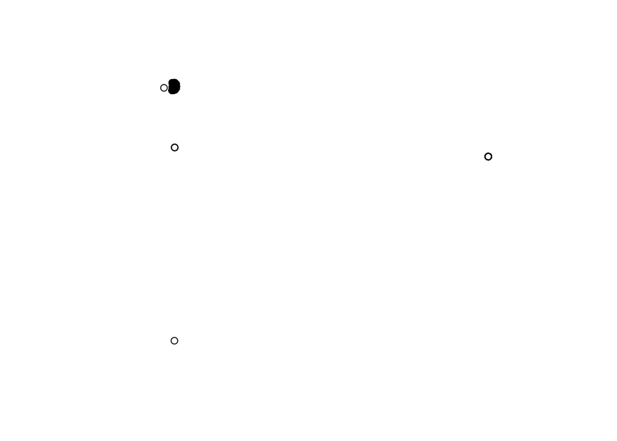

```r
(ARIES.sf %>% filter(county %in% "Marion"))$geometry %>% plot()
```

That dense fuzzy black section in the top-left is where Marion County actually is, but we have several observations outside of that space. Rather than relying on the county variable to be coded correctly, we’ll just use the encoded lat/long for each observation and subset using the geographic boundaries of Marion County.

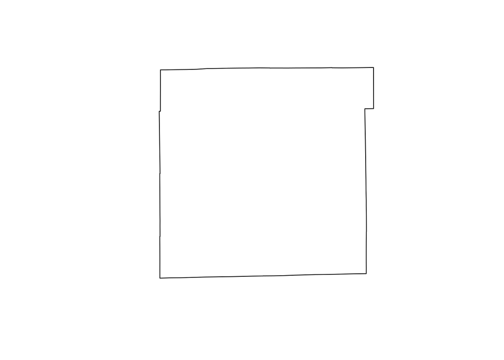

```r
Indy.sf <- st_read("https://xmaps.indy.gov/arcgis/rest/services/OpenData/OpenData_Boundaries/MapServer/9/query?where=1%3D1&text=&objectIds=&time=&geometry=&geometryType=esriGeometryEnvelope&inSR=&spatialRel=esriSpatialRelIntersects&relationParam=&outFields=*&returnGeometry=true&returnTrueCurves=false&maxAllowableOffset=&geometryPrecision=&outSR=&returnIdsOnly=false&returnCountOnly=false&orderByFields=&groupByFieldsForStatistics=&outStatistics=&returnZ=false&returnM=false&gdbVersion=&returnDistinctValues=false&resultOffset=&resultRecordCount=&queryByDistance=&returnExtentsOnly=false&datumTransformation=&parameterValues=&rangeValues=&f=geojson") %>%
  # Transform onto a local Indiana projection
  st_transform(crs = 7327)
plot(Indy.sf$geometry)
```

Now that we have the geographical boundaries of Indianapolis loaded into R, we can select for all crashes that took place within it.

```r
# Identify which crashes took place inside of Indianapolis
inIndy <- st_intersects(ARIES.sf, Indy.sf, sparse = FALSE)

# Display summary of how many crashes took place in Indianapolis vs not
summary(inIndy)
```

```
##      V1
##  Mode :logical
##  FALSE:1943696
##  TRUE :372365
```

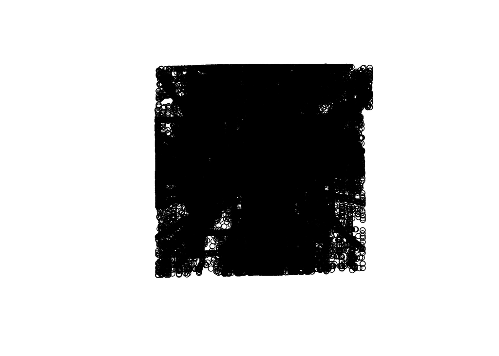

```r
# Select only the crashes that took place Indianapolis
IndyCrashes.sf <- ARIES.sf %>%
  filter(inIndy == TRUE)

# Illustrate distribution of Indianapolis crashes
plot(IndyCrashes.sf$geometry)
```

```r
IndyCrashes.sf %>%
    # Write crashes to the open Geopackage format on disk
    st_write("Indy_Crashes.gpkg")
```

```
## Updating layer `Indy_Crashes' to data source `Indy_Crashes.gpkg' using driver `GPKG'
## Updating existing layer Indy_Crashes
## Writing 372365 features with 18 fields and geometry type Point.
```

This work is licensed under a [Creative Commons Attribution-ShareAlike 4.0 International License](http://creativecommons.org/licenses/by-sa/4.0/).